# tp3

2023-03-27

### TP3

Paul GAULTIER Célien BONHOMME Alexandre GOURNAIL

## Exercise 1

```r
NAm2 = read.table("NAm2.txt", header=TRUE)

cont <- function(x){
  if(x %in% c('Canada'))
    cont <- 'NorthAmerica'
  else if(x %in% c('Guatemala', 'Mexico', 'Panama', 'CostaRica'))
    cont<-'CentralAmerica'
  else
    cont<-'SouthAmerica'
  return(factor(cont))
}
  contID<-sapply(as.character(NAm2[,4]),FUN=cont)
  N <- length(contID)
  dataSet <- NAm2[,-c(1:8)]
```

## Exercise 2

### a)

```r
library("nnet")

NAcont <- data.frame(cbind(contID=contID, NAm2[,-(1:8)]))
NAcont[,1] <- factor(NAcont[,1])
# model <- multinom(contID ~ ., data=NAcont)
# summary(model)
```

We get the following error: “Error in nnet.default(X, Y, w, mask = mask, size = 0, skip = TRUE, softmax = TRUE, : too many (17133) weights”. It occurs because the multinom function is trying to fit a model with a large number of predictor variables (genetic markers) and the default maximum number of weights in the is exceeded.

```r
model <- multinom(contID ~ ., data=NAcont, MaxNWts = 18000, maxit = 200)
```

By setting MaxNWts = 18000 and maxit = 200, we allow for more weights in the model, which was the problem that occured before, and increase the maximum number of iterations to estimate the model.

### b)

```r
pcaNAm2 = prcomp(NAm2[,-c(1:8)], scale = FALSE)$x
NAcontPca<-data.frame(cbind(contID=contID, pcaNAm2))
NAcontPca[,1]<- factor(NAcontPca[,1])
model <- multinom(NAcontPca$contID ~ ., data=NAcontPca, MaxNWts = 1500)
table = table(predict(model, NAcontPca), contID)
table
```

```
##    contID
##     NorthAmerica CentralAmerica SouthAmerica
##   1           67              0            0
##   2            0            159            0
##   3            0              0          268
```

```r
classification_error = 1 - sum(diag(table)) / sum(table)
classification_error
```

```
## [1] 0
```

We see that the model correctly classifies all individuals. This means that the principal components get enough of the variation in the genetic markers that is informative for predicting the continent of origin.

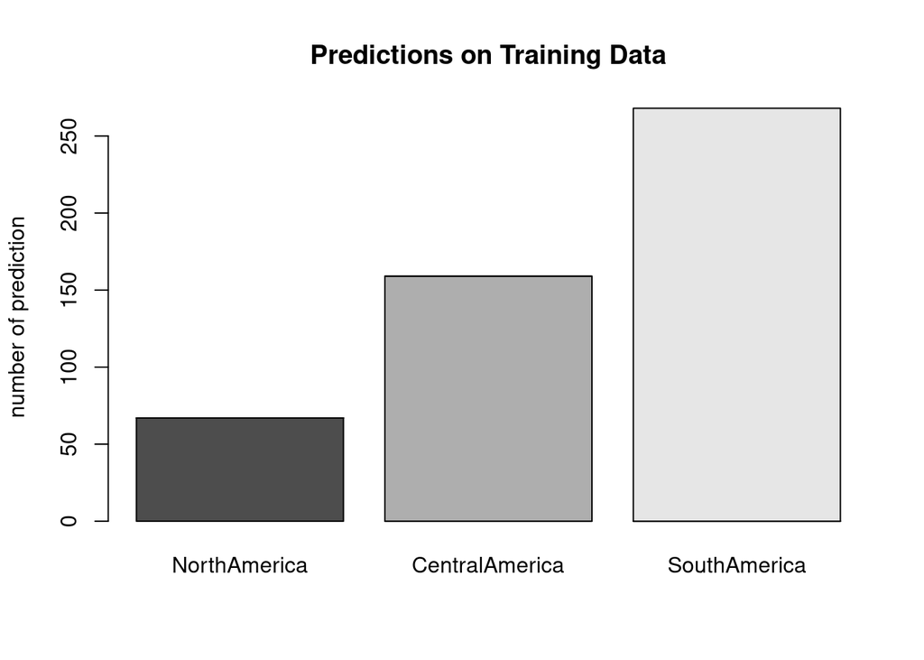

```r
barplot(table,
        main = "Predictions on Training Data",
        ylab = "number of prediction",
        )
```

There is not any error on the training data set prediction. But that does not seems that we will have the same results on validation data, because it could be an over fitting phenomenon.

### c)

```r
K <- 10
subset_idx <- sample((1:N) %% K)

cross_validation <- function(nb_predictors) {
  error_sample_i <- c()
  for (i in 0:K-1) {
    # Definition of the different data sets
    x_train_set <- NAcont[subset_idx != i,]
    x_validation_set <- NAcont[subset_idx == i,]
    y_train_set <- contID[subset_idx != i]
    y_validation_set <- contID[subset_idx == i]

    # we compute the pca, which will be used to create the model
    pca_training <- prcomp(x_train_set[, -1], scale = FALSE)
    # we choose the good number of predictor
    x_pca_training <- pca_training$x[,1:nb_predictors]

    # training of our model
    # model <- multinom(NAcontPca$contID ~ ., data=NAcontPca, MaxNWts = 1500)
    model <- multinom(y_train_set ~ ., data=x_train_set, MaxNWts = 18000, maxit = 20)
    # summary((model))
    # Computation of validation error
    # First, we adapt the validation set by projecting it in the right space with "predict" function
    pca_validation <- predict(pca_training, x_validation_set[, -1])[, 1:nb_predictors]
    # Then we make the prediction on this new set of data
    predictions <- predict(model, newdata = pca_validation)
    error_sample_i <- append(error_sample_i, sum(predictions != y_validation_set)/length(y_validation_set))
  }
  #computation of the error
  return(mean(error_sample_i))
  # mean(error_sample_i)
}
```

The previous function apply a K Fold validation for nb_predictors.

```r
nb_predictors <- seq(from = 20, to = 100, by = 4)
#error_by_predictor_nb <- sapply(nb_predictors, cross_validation)
#error_by_predictor_nb
```

The cross validation function has a problem that we did not managed to solve during the prediction.

```r
min_err <- 10
pc_scores <- pcaNAm2[, 1:min_err]

# Build multinomial regression model
model <- multinom(NAcontPca$contID ~ ., data = NAcontPca, MaxNWts = 18000)
predicted_classes <- predict(model, NAcontPca)

# Compute confusion matrix
table = table(predicted_classes, contID)
table
```

```
##                  contID
## predicted_classes NorthAmerica CentralAmerica SouthAmerica
##                 1           67              0            0
##                 2            0            159            0
##                 3            0              0          268
```

## Exercise 3

```r
library('MASS')
library('class')

pca <- prcomp(dataSet, scale=FALSE)
nParam <- ncol(pca$x)
data <- data.frame(pca$x[,1:nParam], contID=NAcont[,1])
model <- lda(data$contID ~ ., data=data[-c(1, nParam)])
```

There is a problem with the last column of the data set. It appears the last column has a null variance. This is why we delete this predictor from the data set.

```r
predictions <- predict(model, data=data)

table <- table(predictions$class, contID)
table
```

```
##                 contID
##                  NorthAmerica CentralAmerica SouthAmerica
##   NorthAmerica             67              0            0
##   CentralAmerica            0            159            7
##   SouthAmerica              0              0          261
```

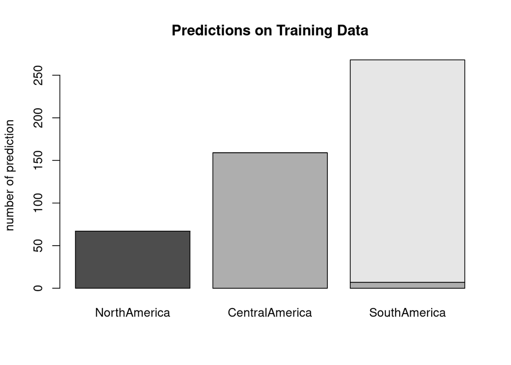

```r
barplot(table,
        main = "Predictions on Training Data",
        ylab = "number of prediction",
        )
```

```r
K <- 10
subset_idx <- sample((1:N) %% K)

#nb_predictors <- 40
#i <- 5

cross_validation <- function(nb_predictors) {
  print(nb_predictors)
  error_sample_i <- c()
  for (i in 0:9) {
    # Definition of the different data sets
    x_train_set <- dataSet[subset_idx != i,]
    x_validation_set <- dataSet[subset_idx == i,]
    y_train_set <- contID[subset_idx != i]
    y_validation_set <- contID[subset_idx == i]

    model <- lda(data$contID ~ ., data=data[-c(1, nParam)])

    # we compute the pca, which will be used to create the model
    pca_training <- prcomp(x_train_set, scale=FALSE)
    # we choose the good number of predictor
    x_pca_training <- data.frame(pca_training$x[,1:nb_predictors], contID=y_train_set)

    # training of our model
    lda_classifier <- lda(x_pca_training$contID ~ ., data=x_pca_training[-c(1, nParam)])

    # Computation of validation error
    # First, we adapt the validation set by projecting it in the right space with "predict" function
    pca_validation <- predict(pca_training, x_validation_set)[,1:nb_predictors]
    # Then we make the prediction on this new set of data
    predictions <- predict(lda_classifier, data.frame(pca_validation))
    error_sample_i <- append(error_sample_i, sum(predictions != y_validation_set)/length(y_validation_set))
    }
  #computation of the error
  return(mean(error_sample_i))
  #mean(error_sample_i)
}
```

At the execution of these lines, we obtain a lot of warnings and a rate of errors of 1 for each set of validation, which means the warnings prevent to have results.

```r
nb_predictors <- seq(from = 20, to = 60, by = 5)

# error_by_predictor_nb <- sapply(nb_predictors, cross_validation)
# error_by_predictor_nb
```

## Exercise 4

```r
library("naivebayes")
```

1. First, we compute the PCA

```r
pca <- prcomp(dataSet, scale=FALSE)
```

Then we train our naive Bayes Bernoulli Classifier and plot its confusion matrix:

```r
bern_classifier <- bernoulli_naive_bayes(pca$x, contID)
summary(bern_classifier)
```

```
##
## ============================= Bernoulli Naive Bayes =============================
##
## - Call: bernoulli_naive_bayes(x = pca$x, y = contID)
## - Laplace: 0
## - Classes: 3
## - Samples: 494
## - Features: 494
## - Prior probabilities:
##     - NorthAmerica: 0.1356
##     - CentralAmerica: 0.3219
##     - SouthAmerica: 0.5425
##
## ---------------------------------------------------------------------------------
```

Then we evaluate the classifier on the data set:

```r
predictions <- predict(bern_classifier, pca$x) # prediction on training data
predictions <- bern_classifier$data$y
confusion_matrix_bern <- table(predict(bern_classifier, pca$x), contID)
confusion_matrix_bern
```

```
##                 contID
##                  NorthAmerica CentralAmerica SouthAmerica
##   NorthAmerica             67              4            5
##   CentralAmerica            0            155           13
##   SouthAmerica              0              0          250
```

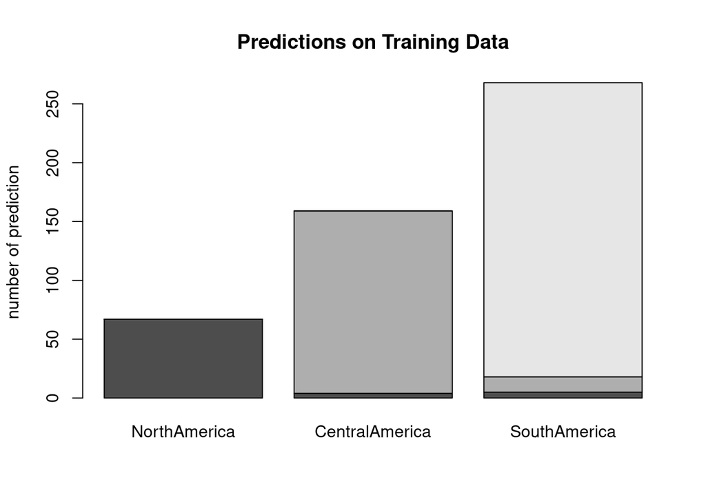

```r
barplot(confusion_matrix_bern,
        main = "Predictions on Training Data",
        ylab = "number of prediction",
        )
```

Now we apply the K-fold cross-validation procedure (with K = 10) to choose the optimum number of predictors in the pca

```r
K <- 10
subset_idx <- sample((1:N) %% K)

cross_validation <- function(nb_predictors) {
  print(nb_predictors)
  error_sample_i <- c()
  for (i in 0:9) {
    # Definition of the different data sets
    x_train_set <- dataSet[subset_idx != i,]
    x_validation_set <- dataSet[subset_idx == i,]
    y_train_set <- contID[subset_idx != i]
    y_validation_set <- contID[subset_idx == i]

    # we compute the pca, which will be used to create the model
    pca_training <- prcomp(x_train_set, scale=FALSE)
    # we choose the good number of predictor
    x_pca_training <- pca_training$x[,1:nb_predictors]

    # training of our model
    bern_classifier <- bernoulli_naive_bayes(x_pca_training, y_train_set)

    # Computation of validation error
    # First, we adapt the validation set by projecting it in the right space with "predict" function
    pca_validation <- predict(pca_training, x_validation_set)[,1:nb_predictors]
    # Then we make the prediction on this new set of data
    predictions <- predict(bern_classifier, pca_validation)
    error_sample_i <- append(error_sample_i, sum(predictions != y_validation_set)/length(y_validation_set))
  }
  #computation of the error
  return(mean(error_sample_i))
  #mean(error_sample_i)
}
```

This function compute the mean error for a given number of predictors by using a 10-cross-validation method. We apply this function to find the best number of predictors for this model.

The calculation is a bit long, this is why we do not plot the error for all the number between 1 and the maximum number of predictors.

```r
nb_predictors <- seq(from = 20, to = 100, by = 4)

error_by_predictor_nb <- sapply(nb_predictors, cross_validation)
```

```
## [1] 20
## [1] 24
## [1] 28
## [1] 32
## [1] 36
## [1] 40
## [1] 44
## [1] 48
## [1] 52
## [1] 56
## [1] 60
## [1] 64
## [1] 68
## [1] 72
## [1] 76
## [1] 80
## [1] 84
## [1] 88
## [1] 92
## [1] 96
## [1] 100
```

```r
error_by_predictor_nb
```

```
##  [1] 0.1396327 0.1254286 0.1253469 0.1355918 0.1275510 0.1336735 0.1214286
##  [8] 0.1234286 0.1173878 0.1195102 0.1214694 0.1295510 0.1294694 0.1253878
## [15] 0.1294286 0.1314286 0.1293878 0.1273469 0.1253878 0.1132245 0.1071429
```

Then we plot the result:

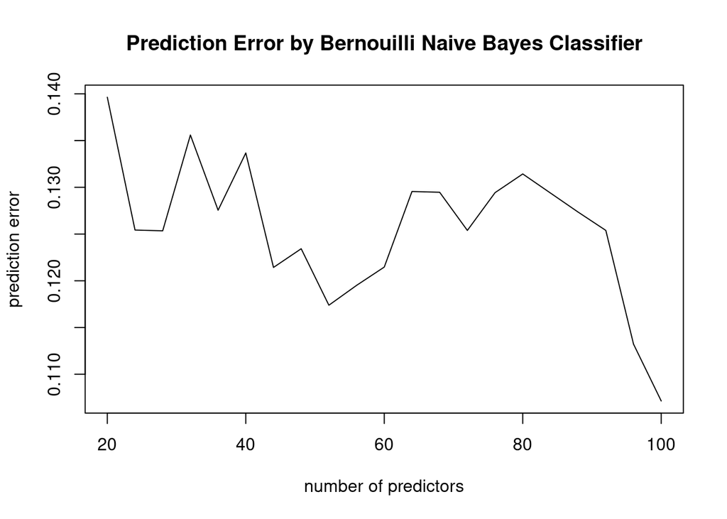

```r
plot(nb_predictors,
     error_by_predictor_nb,
     main = "Prediction Error by Bernouilli Naive Bayes Classifier",
     xlab = "number of predictors",
     ylab = "prediction error",
     type = "l")
```

This graph shows us that the best possible prediction error is

```r
min(error_by_predictor_nb)
```

```
## [1] 0.1071429
```